# Bellabeat Case Study - Google Data Analytics Capstone Project

Ernest Owolabi

2024-03-18

# 1. About The Company

Bellabeat, founded by Urška Sršen and Sando Mur, is a tech company known for its health-focused smart products designed with artistic flair. Since its establishment in 2013, Bellabeat has swiftly become a prominent wellness brand for women, offering insights into activity, sleep, stress, and reproductive health. By 2016, the company had expanded globally, offering its products through various online retailers and its e-commerce platform. Bellabeat prioritizes digital marketing, maintaining an active presence on platforms like Google, Facebook, Instagram, and Twitter, alongside running targeted video and display ads.

# 2. Scenario

Bellabeat, though successful as a small company, aims to expand its presence in the global smart device market. Urška Sršen, co-founder and Chief Creative Officer, sees potential in analyzing smart device fitness data to drive growth. As part of this initiative, I’ve been tasked with analyzing consumer usage data for one of Bellabeat’s products. The insights gained will inform the company’s marketing strategy. My analysis and recommendations will be presented to the Bellabeat executive team for strategic decision-making.

# 3. Business Task

- Conducting market analysis and identifying growth opportunities in the global smart device market.
- Analyzing smart device fitness data to understand consumer behavior and usage patterns.
- Presenting findings and insights to the Bellabeat executive team.
- Formulating high-level recommendations for Bellabeat’s marketing strategy based on the analysis.
- Collaborating with the marketing team to implement the recommended strategies.
- Monitoring and evaluating the effectiveness of the marketing strategies implemented.
- Iterating and refining marketing approaches based on ongoing analysis and feedback.

I will follow these steps of the data analysis process: **ask, prepare, process, analyze, share, and act**.

# 4. Ask

Sršen asks me to analyze smart device usage data in order to gain insight into how consumers use non-Bellabeat smart devices. She then wants me to select one Bellabeat product to apply these insights to in my presentation.

These questions will guide my analysis:

- What are some trends in smart device usage?
- How could these trends apply to Bellabeat customers?
- How could these trends help influence Bellabeat marketing strategy?

I will produce a report with the following deliverables:

- A clear summary of the business task
- A description of all data sources used
- Documentation of any cleaning or manipulation of data
- A summary of my analysis
- Supporting visualizations and key findings
- My top high-level content recommendations based on my analysis

# 5. Prepare

Sršen encouraged me to use public data that explores smart device users’ daily habits. She points to a specific data set: **FitBit Fitness Tracker Data** (CC0: Public Domain, dataset made available through Mobius): This Kaggle data set contains personal fitness tracker from thirty fitbit users. Thirty eligible Fitbit users consented to the submission of personal tracker data, including minute-level output for physical activity, heart rate, and sleep monitoring. It includes information about daily activity, steps, and heart rate that can be used to explore users’ habits. Sršen tells me that this data set might have some limitations, and encourages me to consider adding another data to help address those limitations as i begin to work more with this data.

### 5.2 Limitations

# 6. Process and Analyse

I chose **R** as my tool for analysis because its very convenient to clean, analyse and visualise my data, all in one place.

### 6.1 Install and Load the Packages

```r
library(tidyverse)
library(lubridate)
```

### 6.2 Loading the dataframes

```r
daily_activity <- read_csv("Fitabase Data 4.12.16-5.12.16/dailyActivity_merged.csv")
sleep_day <- read_csv("Fitabase Data 4.12.16-5.12.16/sleepDay_merged.csv")
heartrate_seconds <- read_csv("Fitabase Data 4.12.16-5.12.16/heartrate_seconds_merged.csv")
weight <- read_csv("Fitabase Data 4.12.16-5.12.16/weightLogInfo_merged.csv")
```

#### 6.2.1 Exploring the loaded dataframes

```r
head(daily_activity)
```

```
## # A tibble: 6 × 15
##           Id ActivityDate TotalSteps TotalDistance TrackerDistance
##        <dbl> <chr>             <dbl>         <dbl>           <dbl>
## 1 1503960366 4/12/2016         13162          8.5             8.5
## 2 1503960366 4/13/2016         10735          6.97            6.97
## 3 1503960366 4/14/2016         10460          6.74            6.74
## 4 1503960366 4/15/2016          9762          6.28            6.28
## 5 1503960366 4/16/2016         12669          8.16            8.16
## 6 1503960366 4/17/2016          9705          6.48            6.48
## # ℹ 10 more variables: LoggedActivitiesDistance <dbl>,
## #   VeryActiveDistance <dbl>, ModeratelyActiveDistance <dbl>,
## #   LightActiveDistance <dbl>, SedentaryActiveDistance <dbl>,
## #   VeryActiveMinutes <dbl>, FairlyActiveMinutes <dbl>,
## #   LightlyActiveMinutes <dbl>, SedentaryMinutes <dbl>, Calories <dbl>
```

```r
head(sleep_day)
```

```
## # A tibble: 6 × 5
##           Id SleepDay        TotalSleepRecords TotalMinutesAsleep TotalTimeInBed
##        <dbl> <chr>                       <dbl>              <dbl>          <dbl>
## 1 1503960366 4/12/2016 12:0…                 1                327            346
## 2 1503960366 4/13/2016 12:0…                 2                384            407
## 3 1503960366 4/15/2016 12:0…                 1                412            442
## 4 1503960366 4/16/2016 12:0…                 2                340            367
## 5 1503960366 4/17/2016 12:0…                 1                700            712
## 6 1503960366 4/19/2016 12:0…                 1                304            320
```

```r
head(weight)
```

```
## # A tibble: 6 × 8
##           Id Date       WeightKg WeightPounds   Fat   BMI IsManualReport   LogId
##        <dbl> <chr>         <dbl>        <dbl> <dbl> <dbl> <lgl>            <dbl>
## 1 1503960366 5/2/2016 …     52.6         116.    22  22.6 TRUE           1.46e12
## 2 1503960366 5/3/2016 …     52.6         116.    NA  22.6 TRUE           1.46e12
## 3 1927972279 4/13/2016…    134.          294.    NA  47.5 FALSE          1.46e12
## 4 2873212765 4/21/2016…     56.7         125.    NA  21.5 TRUE           1.46e12
## 5 2873212765 5/12/2016…     57.3         126.    NA  21.7 TRUE           1.46e12
## 6 4319703577 4/17/2016…     72.4         160.    25  27.5 TRUE           1.46e12
```

```r
head(heartrate_seconds)
```

```
## # A tibble: 6 × 3
##           Id Time                 Value
##        <dbl> <chr>                <dbl>
## 1 2022484408 4/12/2016 7:21:00 AM    97
## 2 2022484408 4/12/2016 7:21:05 AM   102
## 3 2022484408 4/12/2016 7:21:10 AM   105
## 4 2022484408 4/12/2016 7:21:20 AM   103
## 5 2022484408 4/12/2016 7:21:25 AM   101
## 6 2022484408 4/12/2016 7:22:05 AM    95
```

```r
colnames(daily_activity)
```

```
##  [1] "Id"                       "ActivityDate"
##  [3] "TotalSteps"               "TotalDistance"
##  [5] "TrackerDistance"          "LoggedActivitiesDistance"
##  [7] "VeryActiveDistance"       "ModeratelyActiveDistance"
##  [9] "LightActiveDistance"      "SedentaryActiveDistance"
## [11] "VeryActiveMinutes"        "FairlyActiveMinutes"
## [13] "LightlyActiveMinutes"     "SedentaryMinutes"
## [15] "Calories"
```

```r
colnames(sleep_day)
```

```
## [1] "Id"                 "SleepDay"           "TotalSleepRecords"
## [4] "TotalMinutesAsleep" "TotalTimeInBed"
```

```r
colnames(weight)
```

```
## [1] "Id"             "Date"           "WeightKg"       "WeightPounds"
## [5] "Fat"            "BMI"            "IsManualReport" "LogId"
```

```r
colnames(heartrate_seconds)
```

```
## [1] "Id"    "Time"  "Value"
```

```r
str(daily_activity)
```

```
## spc_tbl_ [940 × 15] (S3: spec_tbl_df/tbl_df/tbl/data.frame)
##  $ Id                      : num [1:940] 1.5e+09 1.5e+09 1.5e+09 1.5e+09 1.5e+09 ...
##  $ ActivityDate            : chr [1:940] "4/12/2016" "4/13/2016" "4/14/2016" "4/15/2016" ...
##  $ TotalSteps              : num [1:940] 13162 10735 10460 9762 12669 ...
##  $ TotalDistance           : num [1:940] 8.5 6.97 6.74 6.28 8.16 ...
##  $ TrackerDistance         : num [1:940] 8.5 6.97 6.74 6.28 8.16 ...
##  $ LoggedActivitiesDistance: num [1:940] 0 0 0 0 0 0 0 0 0 0 ...
##  $ VeryActiveDistance      : num [1:940] 1.88 1.57 2.44 2.14 2.71 ...
##  $ ModeratelyActiveDistance: num [1:940] 0.55 0.69 0.4 1.26 0.41 ...
##  $ LightActiveDistance     : num [1:940] 6.06 4.71 3.91 2.83 5.04 ...
##  $ SedentaryActiveDistance : num [1:940] 0 0 0 0 0 0 0 0 0 0 ...
##  $ VeryActiveMinutes       : num [1:940] 25 21 30 29 36 38 42 50 28 19 ...
##  $ FairlyActiveMinutes     : num [1:940] 13 19 11 34 10 20 16 31 12 8 ...
##  $ LightlyActiveMinutes    : num [1:940] 328 217 181 209 221 164 233 264 205 211 ...
##  $ SedentaryMinutes        : num [1:940] 728 776 1218 726 773 ...
##  $ Calories                : num [1:940] 1985 1797 1776 1745 1863 ...
##  - attr(*, "spec")=
##   .. cols(
##   ..   Id = col_double(),
##   ..   ActivityDate = col_character(),
##   ..   TotalSteps = col_double(),
##   ..   TotalDistance = col_double(),
##   ..   TrackerDistance = col_double(),
##   ..   LoggedActivitiesDistance = col_double(),
##   ..   VeryActiveDistance = col_double(),
##   ..   ModeratelyActiveDistance = col_double(),
##   ..   LightActiveDistance = col_double(),
##   ..   SedentaryActiveDistance = col_double(),
##   ..   VeryActiveMinutes = col_double(),
##   ..   FairlyActiveMinutes = col_double(),
##   ..   LightlyActiveMinutes = col_double(),
##   ..   SedentaryMinutes = col_double(),
##   ..   Calories = col_double()
##   .. )
##  - attr(*, "problems")=<externalptr>
```

```r
str(sleep_day)
```

```
## spc_tbl_ [413 × 5] (S3: spec_tbl_df/tbl_df/tbl/data.frame)
##  $ Id                : num [1:413] 1.5e+09 1.5e+09 1.5e+09 1.5e+09 1.5e+09 ...
##  $ SleepDay          : chr [1:413] "4/12/2016 12:00:00 AM" "4/13/2016 12:00:00 AM" "4/15/2016 12:00:00 AM" "4/16/2016 12:00:00 AM" ...
##  $ TotalSleepRecords : num [1:413] 1 2 1 2 1 1 1 1 1 1 ...
##  $ TotalMinutesAsleep: num [1:413] 327 384 412 340 700 304 360 325 361 430 ...
##  $ TotalTimeInBed    : num [1:413] 346 407 442 367 712 320 377 364 384 449 ...
##  - attr(*, "spec")=
##   .. cols(
##   ..   Id = col_double(),
##   ..   SleepDay = col_character(),
##   ..   TotalSleepRecords = col_double(),
##   ..   TotalMinutesAsleep = col_double(),
##   ..   TotalTimeInBed = col_double()
##   .. )
##  - attr(*, "problems")=<externalptr>
```

```r
str(weight)
```

```
## spc_tbl_ [67 × 8] (S3: spec_tbl_df/tbl_df/tbl/data.frame)
##  $ Id            : num [1:67] 1.50e+09 1.50e+09 1.93e+09 2.87e+09 2.87e+09 ...
##  $ Date          : chr [1:67] "5/2/2016 11:59:59 PM" "5/3/2016 11:59:59 PM" "4/13/2016 1:08:52 AM" "4/21/2016 11:59:59 PM" ...
##  $ WeightKg      : num [1:67] 52.6 52.6 133.5 56.7 57.3 ...
##  $ WeightPounds  : num [1:67] 116 116 294 125 126 ...
##  $ Fat           : num [1:67] 22 NA NA NA NA 25 NA NA NA NA ...
##  $ BMI           : num [1:67] 22.6 22.6 47.5 21.5 21.7 ...
##  $ IsManualReport: logi [1:67] TRUE TRUE FALSE TRUE TRUE TRUE ...
##  $ LogId         : num [1:67] 1.46e+12 1.46e+12 1.46e+12 1.46e+12 1.46e+12 ...
##  - attr(*, "spec")=
##   .. cols(
##   ..   Id = col_double(),
##   ..   Date = col_character(),
##   ..   WeightKg = col_double(),
##   ..   WeightPounds = col_double(),
##   ..   Fat = col_double(),
##   ..   BMI = col_double(),
##   ..   IsManualReport = col_logical(),
##   ..   LogId = col_double()
##   .. )
##  - attr(*, "problems")=<externalptr>
```

```r
str(heartrate_seconds)
```

```
## spc_tbl_ [2,483,658 × 3] (S3: spec_tbl_df/tbl_df/tbl/data.frame)
##  $ Id   : num [1:2483658] 2.02e+09 2.02e+09 2.02e+09 2.02e+09 2.02e+09 ...
##  $ Time : chr [1:2483658] "4/12/2016 7:21:00 AM" "4/12/2016 7:21:05 AM" "4/12/2016 7:21:10 AM" "4/12/2016 7:21:20 AM" ...
##  $ Value: num [1:2483658] 97 102 105 103 101 95 91 93 94 93 ...
##  - attr(*, "spec")=
##   .. cols(
##   ..   Id = col_double(),
##   ..   Time = col_character(),
##   ..   Value = col_double()
##   .. )
##  - attr(*, "problems")=<externalptr>
```

#### 6.2.2 To see distinct participants in all the data frames

```r
n_distinct(daily_activity$Id)
```

```
## [1] 33
```

```r
n_distinct(sleep_day$Id)
```

```
## [1] 24
```

```r
n_distinct(weight$Id)
```

```
## [1] 8
```

```r
n_distinct(heartrate_seconds$Id)
```

```
## [1] 14
```

#### 6.2.3 Check for duplicates

```r
sum(duplicated(daily_activity))
```

```
## [1] 0
```

```r
sum(duplicated(sleep_day))
```

```
## [1] 3
```

```r
sum(duplicated(weight))
```

```
## [1] 0
```

```r
sum(duplicated(heartrate_seconds))
```

```
## [1] 0
```

###### 6.2.3.1 Remove duplicates

```r
sleep_day_2 <- sleep_day %>%
  distinct()
sum(duplicated(sleep_day_2))
```

```
## [1] 0
```

### 6.3 Summarise data to get insights

```r
daily_activity %>%
  select(TotalSteps,TotalDistance,SedentaryMinutes,Calories) %>%
  summary()
```

```
##    TotalSteps    TotalDistance    SedentaryMinutes    Calories
##  Min.   :    0   Min.   : 0.000   Min.   :   0.0   Min.   :   0
##  1st Qu.: 3790   1st Qu.: 2.620   1st Qu.: 729.8   1st Qu.:1828
##  Median : 7406   Median : 5.245   Median :1057.5   Median :2134
##  Mean   : 7638   Mean   : 5.490   Mean   : 991.2   Mean   :2304
##  3rd Qu.:10727   3rd Qu.: 7.713   3rd Qu.:1229.5   3rd Qu.:2793
##  Max.   :36019   Max.   :28.030   Max.   :1440.0   Max.   :4900
```

```r
daily_activity %>%
  select(VeryActiveMinutes, FairlyActiveMinutes, LightlyActiveMinutes) %>%
  summary()
```

```
##  VeryActiveMinutes FairlyActiveMinutes LightlyActiveMinutes
##  Min.   :  0.00    Min.   :  0.00      Min.   :  0.0
##  1st Qu.:  0.00    1st Qu.:  0.00      1st Qu.:127.0
##  Median :  4.00    Median :  6.00      Median :199.0
##  Mean   : 21.16    Mean   : 13.56      Mean   :192.8
##  3rd Qu.: 32.00    3rd Qu.: 19.00      3rd Qu.:264.0
##  Max.   :210.00    Max.   :143.00      Max.   :518.0
```

```r
sleep_day_2 %>%
  select(TotalSleepRecords,TotalMinutesAsleep,TotalTimeInBed) %>%
  summary()
```

```
##  TotalSleepRecords TotalMinutesAsleep TotalTimeInBed
##  Min.   :1.00      Min.   : 58.0      Min.   : 61.0
##  1st Qu.:1.00      1st Qu.:361.0      1st Qu.:403.8
##  Median :1.00      Median :432.5      Median :463.0
##  Mean   :1.12      Mean   :419.2      Mean   :458.5
##  3rd Qu.:1.00      3rd Qu.:490.0      3rd Qu.:526.0
##  Max.   :3.00      Max.   :796.0      Max.   :961.0
```

```r
heartrate_seconds %>%
  select(Value) %>%
  summary()
```

```
##      Value
##  Min.   : 36.00
##  1st Qu.: 63.00
##  Median : 73.00
##  Mean   : 77.33
##  3rd Qu.: 88.00
##  Max.   :203.00
```

```r
weight %>%
  select(WeightKg,BMI) %>%
  summary()
```

```
##     WeightKg           BMI
##  Min.   : 52.60   Min.   :21.45
##  1st Qu.: 61.40   1st Qu.:23.96
##  Median : 62.50   Median :24.39
##  Mean   : 72.04   Mean   :25.19
##  3rd Qu.: 85.05   3rd Qu.:25.56
##  Max.   :133.50   Max.   :47.54
```

#### 6.3.1 Daily Activity Insights

**Steps**: The summary shows that the average steps per day is 7638 steps.

**Sedentary Minutes**: Participants have an average of 991 sedentary minutes.

**Sleep**: Participants slept for an average of 419 minutes and stayed in bed for 458 minutes.

**Calories**: The average calories burned per day is 2304.

**Active**: More participants are lightly active.

**Heart Rate**: Participants have an average of 77bpm.

**Weight**: Users have an average weight of 72kg and average BMI of 25.19.

### 6.4 Merging Dataframes

#### 6.4.1 Change Date Format

To merge Dataframes,I have to ensure consistency of the date columns between the daily_activity and sleep_day dataframes. First of all, I renamed all date formats to be consistent across all dataframes, then I trimmed to remove leading and trailing spaces.

```r
daily_activity2 <- daily_activity %>%
  mutate(ActivityDate=trimws(ActivityDate)) %>%
  rename(Date=ActivityDate)
sleep_day_3 <- sleep_day_2 %>%
  mutate(SleepDay=trimws(SleepDay)) %>%
  rename(Date=SleepDay)
heartrate_seconds2 <- heartrate_seconds %>%
  mutate(Time=trimws(Time)) %>%
  rename(Date=Time)
weight2 <- weight %>%
  mutate(Date=trimws(Date))
```

#### 6.4.2 Now to convert to date format

First convert the daily activity dataframe

```r
daily_activity_cleaned <- daily_activity2 %>%
  mutate(Date=as_date(Date,format="%m/%d/%Y"))
str(daily_activity_cleaned)
```

```
## tibble [940 × 15] (S3: tbl_df/tbl/data.frame)
##  $ Id                      : num [1:940] 1.5e+09 1.5e+09 1.5e+09 1.5e+09 1.5e+09 ...
##  $ Date                    : Date[1:940], format: "2016-04-12" "2016-04-13" ...
##  $ TotalSteps              : num [1:940] 13162 10735 10460 9762 12669 ...
##  $ TotalDistance           : num [1:940] 8.5 6.97 6.74 6.28 8.16 ...
##  $ TrackerDistance         : num [1:940] 8.5 6.97 6.74 6.28 8.16 ...
##  $ LoggedActivitiesDistance: num [1:940] 0 0 0 0 0 0 0 0 0 0 ...
##  $ VeryActiveDistance      : num [1:940] 1.88 1.57 2.44 2.14 2.71 ...
##  $ ModeratelyActiveDistance: num [1:940] 0.55 0.69 0.4 1.26 0.41 ...
##  $ LightActiveDistance     : num [1:940] 6.06 4.71 3.91 2.83 5.04 ...
##  $ SedentaryActiveDistance : num [1:940] 0 0 0 0 0 0 0 0 0 0 ...
##  $ VeryActiveMinutes       : num [1:940] 25 21 30 29 36 38 42 50 28 19 ...
##  $ FairlyActiveMinutes     : num [1:940] 13 19 11 34 10 20 16 31 12 8 ...
##  $ LightlyActiveMinutes    : num [1:940] 328 217 181 209 221 164 233 264 205 211 ...
##  $ SedentaryMinutes        : num [1:940] 728 776 1218 726 773 ...
##  $ Calories                : num [1:940] 1985 1797 1776 1745 1863 ...
```

```r
View(daily_activity_cleaned)
```

Now to convert the sleep dataframe

```r
sleep_day_cleaned <- sleep_day_3 %>%
  mutate(Date=as.Date(Date,format="%m/%d/%Y %I:%M:%S %p"))
View(sleep_day_cleaned)
str(sleep_day_cleaned)
```

```
## tibble [410 × 5] (S3: tbl_df/tbl/data.frame)
##  $ Id                : num [1:410] 1.5e+09 1.5e+09 1.5e+09 1.5e+09 1.5e+09 ...
##  $ Date              : Date[1:410], format: "2016-04-12" "2016-04-13" ...
##  $ TotalSleepRecords : num [1:410] 1 2 1 2 1 1 1 1 1 1 ...
##  $ TotalMinutesAsleep: num [1:410] 327 384 412 340 700 304 360 325 361 430 ...
##  $ TotalTimeInBed    : num [1:410] 346 407 442 367 712 320 377 364 384 449 ...
```

Then the weight dataframes These conversions are necessary because im going to merge these data frames.

```r
weight_cleaned <- weight2 %>%
  mutate(Date=as.Date(Date,format="%m/%d/%Y %I:%M:%S %p"))
View(weight_cleaned)
str(weight_cleaned)
```

```
## tibble [67 × 8] (S3: tbl_df/tbl/data.frame)
##  $ Id            : num [1:67] 1.50e+09 1.50e+09 1.93e+09 2.87e+09 2.87e+09 ...
##  $ Date          : Date[1:67], format: "2016-05-02" "2016-05-03" ...
##  $ WeightKg      : num [1:67] 52.6 52.6 133.5 56.7 57.3 ...
##  $ WeightPounds  : num [1:67] 116 116 294 125 126 ...
##  $ Fat           : num [1:67] 22 NA NA NA NA 25 NA NA NA NA ...
##  $ BMI           : num [1:67] 22.6 22.6 47.5 21.5 21.7 ...
##  $ IsManualReport: logi [1:67] TRUE TRUE FALSE TRUE TRUE TRUE ...
##  $ LogId         : num [1:67] 1.46e+12 1.46e+12 1.46e+12 1.46e+12 1.46e+12 ...
```

#### 6.4.3 Now to merge dataframes

I merged the activity and sleep data frames together in order to analyse the relationship between them and get insights.

```r
daily_merged_data <- merge(sleep_day_cleaned, daily_activity_cleaned, by=c('Id','Date'))
head(daily_merged_data)
```

```
##           Id       Date TotalSleepRecords TotalMinutesAsleep TotalTimeInBed
## 1 1503960366 2016-04-12                 1                327            346
## 2 1503960366 2016-04-13                 2                384            407
## 3 1503960366 2016-04-15                 1                412            442
## 4 1503960366 2016-04-16                 2                340            367
## 5 1503960366 2016-04-17                 1                700            712
## 6 1503960366 2016-04-19                 1                304            320
##   TotalSteps TotalDistance TrackerDistance LoggedActivitiesDistance
## 1      13162          8.50            8.50                        0
## 2      10735          6.97            6.97                        0
## 3       9762          6.28            6.28                        0
## 4      12669          8.16            8.16                        0
## 5       9705          6.48            6.48                        0
## 6      15506          9.88            9.88                        0
##   VeryActiveDistance ModeratelyActiveDistance LightActiveDistance
```

[output cut: 20 more lines]

```r
View(daily_merged_data)
```

Then I proceeded to merge the daily activity and weight dataframes

```r
daily_activity_weight <- merge(weight_cleaned, daily_activity_cleaned, by=c('Id','Date'))
head(daily_activity_weight)
```

```
##           Id       Date WeightKg WeightPounds Fat   BMI IsManualReport
## 1 1503960366 2016-05-02     52.6     115.9631  22 22.65           TRUE
## 2 1503960366 2016-05-03     52.6     115.9631  NA 22.65           TRUE
## 3 1927972279 2016-04-13    133.5     294.3171  NA 47.54          FALSE
## 4 2873212765 2016-04-21     56.7     125.0021  NA 21.45           TRUE
## 5 2873212765 2016-05-12     57.3     126.3249  NA 21.69           TRUE
## 6 4319703577 2016-04-17     72.4     159.6147  25 27.45           TRUE
##          LogId TotalSteps TotalDistance TrackerDistance
## 1 1.462234e+12      14727          9.71            9.71
## 2 1.462320e+12      15103          9.66            9.66
## 3 1.460510e+12        356          0.25            0.25
## 4 1.461283e+12       8859          5.98            5.98
## 5 1.463098e+12       7566          5.11            5.11
## 6 1.460938e+12         29          0.02            0.02
##   LoggedActivitiesDistance VeryActiveDistance ModeratelyActiveDistance
```

[output cut: 20 more lines]

```r
View(daily_activity_weight)
```

### 6.5 Visualizations

#### 6.5.1 Visualise the relationship between Steps taken and Calories expended

I wanted to know if there was a correlation between steps taken and calories expended I created a scatterplot to show this relationship.

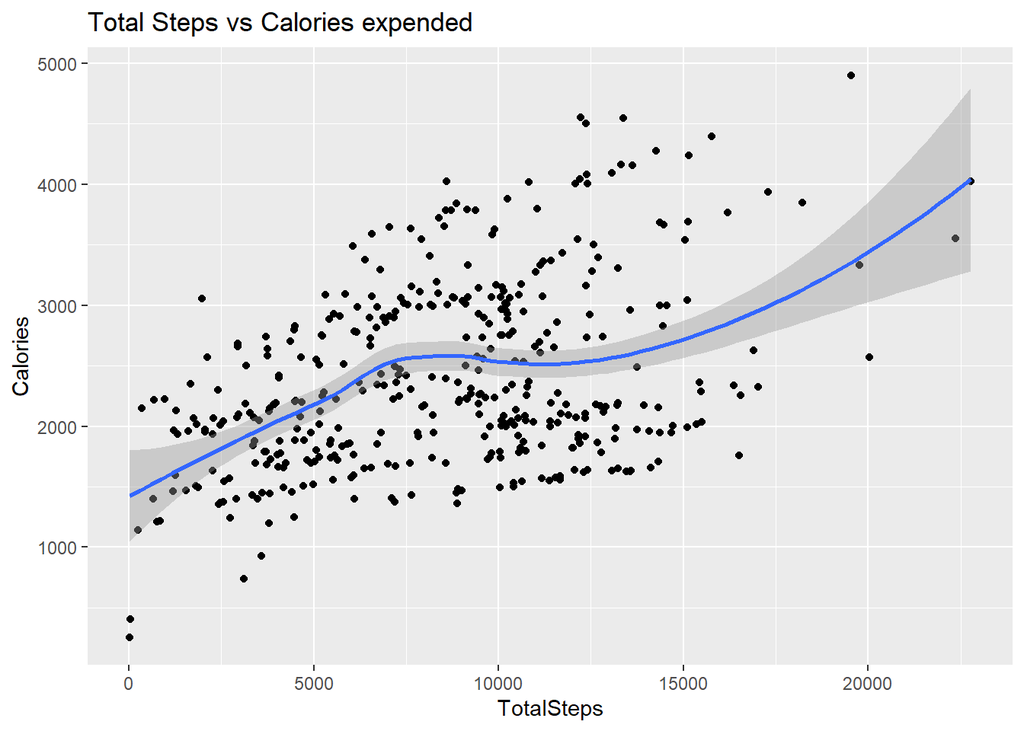

```r
ggplot(data=daily_merged_data, aes(x=TotalSteps, y=Calories)) +
  geom_point() + geom_smooth() + labs(title="Total Steps vs Calories expended")
```

###### 6.5.1.1 Insights

A clear positive correlation emerges between the number of steps taken and the calories expended. This suggests that the greater the number of steps walked, the higher the potential calorie burned.

#### 6.5.2 Visualisation of Daily steps and sleep

To see the relationship between daily steps and sleep, I created another scatterplot.

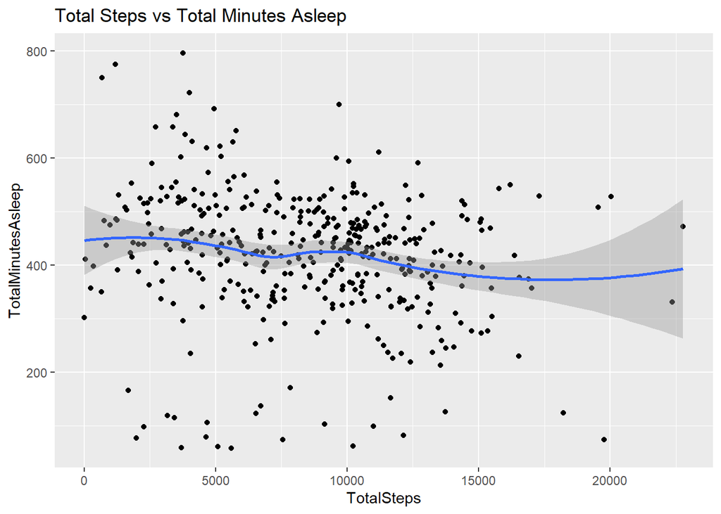

```r
ggplot(data=daily_merged_data, aes(x=TotalSteps, y=TotalMinutesAsleep)) +
  geom_point() + geom_smooth() + labs(title="Total Steps vs Total Minutes Asleep")
```

###### 6.5.2.1 Insights

Here, it appears that there is no discernible correlation between the total number of steps taken and the total minutes asleep.

#### 6.5.3 Visualisation of Distance and Total Calories expended

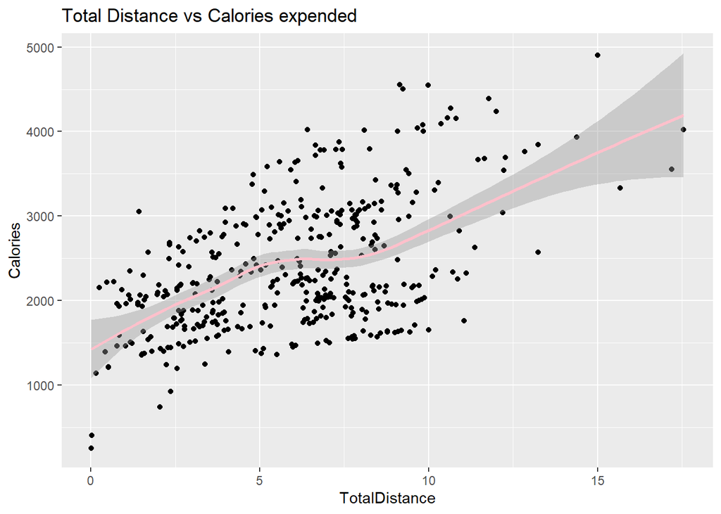

```r
ggplot(daily_merged_data, aes(x=TotalDistance,y= Calories))+
  geom_point() +
  geom_smooth(col='pink') +
  labs(title="Total Distance vs Calories expended")
```

###### 6.5.3.1 Insights

A positive correlation between distance covered and total calories burned is evident from the plotted data.

#### 6.5.4 Use of smart device

To get the daily usage of the smart device, I will use the group by and summarise function to count distinct users and how often they used the device. Grouping into “low use”, “moderate use” and “high use”.

```r
daily_use <- daily_merged_data %>%
  group_by(Id) %>%
  summarize(days_used=sum(n())) %>%
  mutate(usage = case_when(
    days_used >= 1 & days_used <= 10 ~ "low use",
    days_used >= 11 & days_used <= 20 ~ "moderate use",
    days_used >= 21 & days_used <= 31 ~ "high use",
  ))
View(daily_use)
n_distinct(daily_merged_data$Id)
```

```
## [1] 24
```

Visualization of smart device usage data.

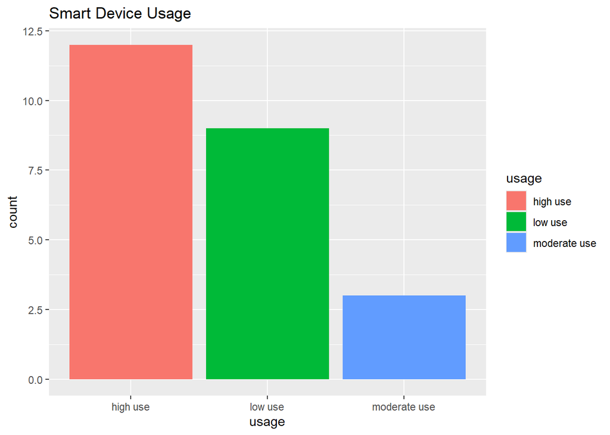

```r
ggplot(data=daily_use)+
  geom_bar(mapping=aes(x=usage, fill=usage))+
  labs(title="Smart Device Usage")
```

#### 6.5.5 Visualisation of BMI against steps taken

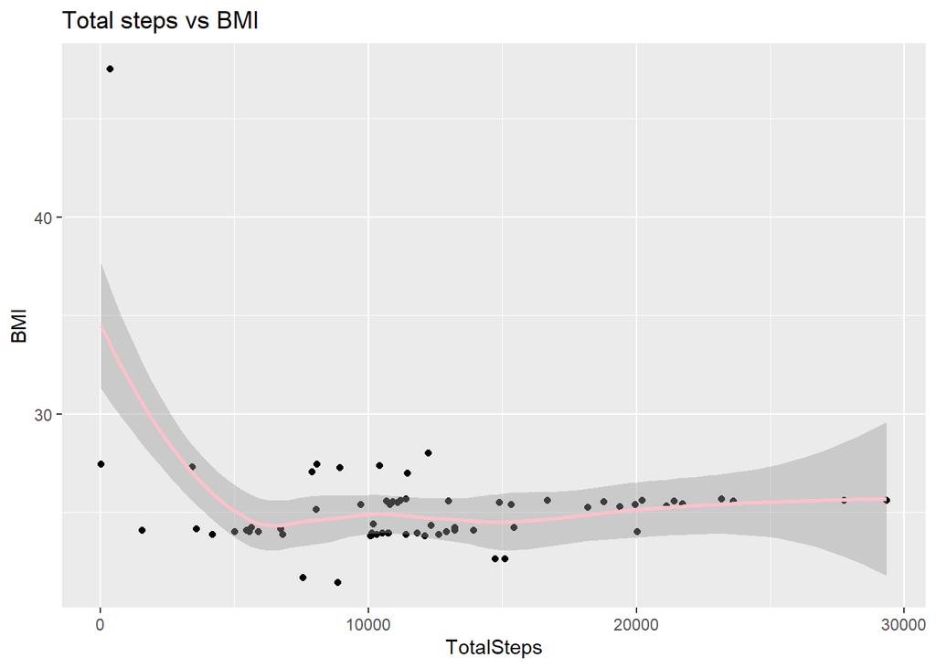

```r
ggplot(data = daily_activity_weight, aes(x = TotalSteps, y = BMI)) +
  geom_point() +
  geom_smooth(col = 'pink')+
  labs(title="Total steps vs BMI")
```

Visualization of BMI against calories expended.

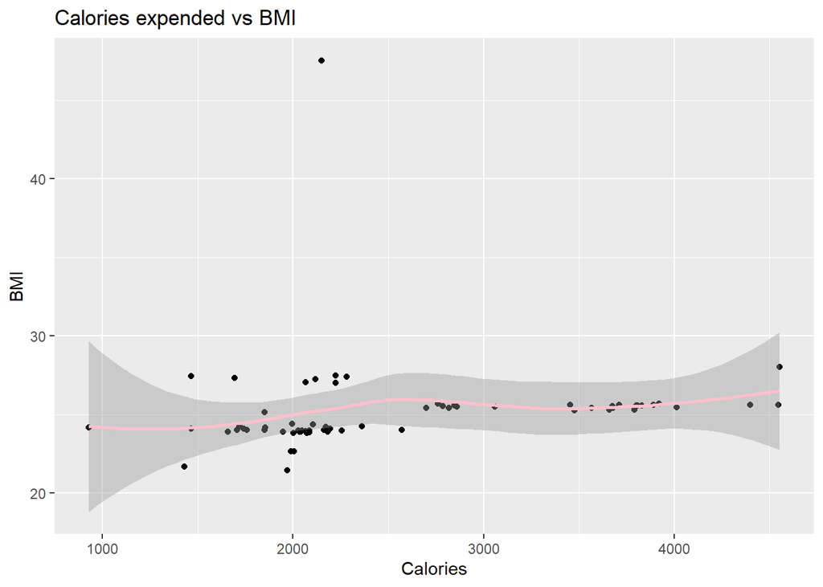

```r
ggplot(data = daily_activity_weight, aes(x = Calories, y = BMI)) +
  geom_point() +
  geom_smooth(col = 'pink')+
  labs(title="Calories expended vs BMI")
```

#### 6.5.6 Visualization for Most active day of the week

First I will extract the days of the week from the date then proceed to analyze.

```r
Day <- daily_activity_cleaned %>%
  mutate(DayOfWeek = weekdays(Date))
View(Day)
```

Convert ‘DayOfWeek’ column into a factor with custom levels specifying the order of days of the week

```r
Day$DayOfWeek <- factor(Day$DayOfWeek, levels = c("Sunday", "Monday", "Tuesday", "Wednesday", "Thursday", "Friday", "Saturday"))
```

Sort the data frame by the ‘DayOfWeek’ column

```r
Day <- Day[order(Day$DayOfWeek), ]
View(Day)
```

Visualization of most active weekdays

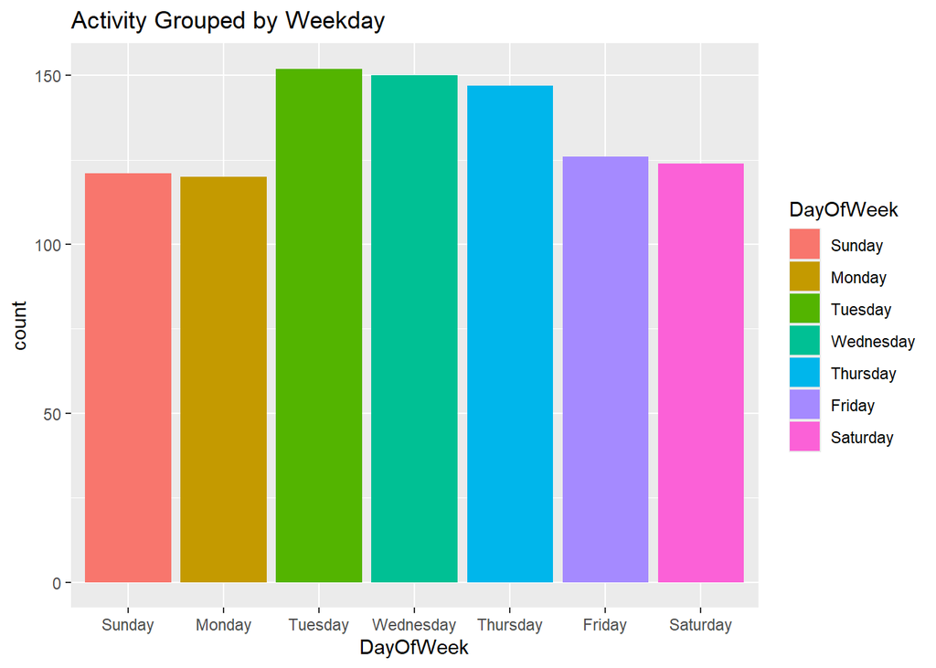

```r
ggplot(data=Day,)+
  geom_bar(mapping=aes(x=DayOfWeek, fill=DayOfWeek))+
  labs(title="Activity Grouped by Weekday")
```

###### 6.5.6.1 Insights

Peak user engagement is observed mid-week, particularly on Tuesday and Wednesday, in terms of the number of times users utilized the app per day. Conversely, Sunday and Monday demonstrates the lowest engagement, suggesting potential opportunities to enhance user activity on these days.

# 7. Findings

**Average Steps per Day**: Participants take an average of 7638 steps daily, indicating their level of physical activity.

**Sedentary Behavior**: On average, participants spend 991 minutes in sedentary activities, highlighting potential areas for improvement in physical activity levels.

**Sleep Duration**: Participants sleep for an average of 419 minutes and stay in bed for 458 minutes, suggesting a relatively consistent sleep pattern.

**Calories Burned**: The average daily calorie expenditure is 2304, which provides insight into participants’ energy expenditure.

**Activity Level**: More participants are lightly active, indicating the predominant activity intensity level among users.

**Heart Rate**: The average heart rate among users is 77 beats per minute (bpm), which may serve as a reference for assessing cardiovascular health.

**Weight and BMI**: Users have an average weight of 72kg and an average BMI of 25.19, indicating the distribution of body weight among participants.

**In addition to these,**

**Correlation between Steps and Calories**: There is a clear positive correlation between the number of steps taken and the calories expended. This suggests that as the number of steps walked increases, there is a corresponding increase in potential calories burned.

**Steps Taken and Sleep Duration**: Interestingly, there seems to be no discernible correlation between the total number of steps taken and the total minutes asleep, indicating that physical activity may not directly affect sleep duration among participants.

**User Engagement Trends**: Peak user engagement is observed mid-week, particularly on Tuesday and Wednesday, in terms of the number of times users utilize the app per day. Conversely, Sunday and Monday demonstrate the lowest engagement, indicating potential opportunities to enhance user activity on these days.

# 8. Recommendations

Based on the insights gathered from the analysis, here are some recommendations for Bellabeat:

**Encourage Physical Activity**: Develop features in smart devices and the app to promote physical activity, such as reminders, personalized goals, and guided workouts.

**Improve Sleep Quality**: Provide insights and tips within the app to enhance sleep quality, including tracking sleep patterns and offering relaxation techniques.

**Enhance Calorie Management**: Offer tools for better calorie intake and expenditure management, like tracking, meal planning, and nutritional information.

**Promote Heart Health**: Utilize average heart rate data to provide insights into cardiovascular health and offer guidance on maintaining a healthy heart rate.

**Tailor Marketing Strategies**: Customize marketing campaigns based on BMI categories, focusing on promoting activity and healthy choices tailored to different user demographics.

**Enhance User Engagement**: Implement strategies to increase engagement, particularly on low-activity days like Sundays and Mondays, through incentives, new features, and community support.

**Additionally**:

- Implement personalized activity goals to motivate users and manage calorie expenditure effectively.
- Provide educational content on sleep hygiene and integrate features to support healthy sleep habits.
- Conduct user surveys to understand barriers to device usage and address them through improved onboarding and user experience.
- Develop fitness programs tailored to different BMI levels and incentivize user engagement through rewards.
- Strategically schedule app updates and promotions to align with peak engagement periods and boost user activity and retention.

By incorporating these recommendations, Bellabeat can empower users to lead healthier lives and solidify its position as a leader in smart wellness solutions.